# Multiple Regression Course Project

Jacob M. Lundeen

13 March 2019

## Executive Summary

Through the use of central tendency analysis with the confirmation by multiple regression to the formula mpg ~ am + wt + hp + (am * wt), we find that, in 1974, manual transmissions tended to be more fuel efficient than automatic transmissions.

## Introduction: Automatics versus Manuals

Which transmission type is more fuel efficient, automatics or manuals? This has long been a question posed by automotive enthusiasts for many decades. This analysis, using data collected by *Motor Trend* in 1974, will apply multiple regression models to that data in an attempt to answer that question.

We start off with looking over the data, looking to understand what exactly we are looking at, looking for anything that seems out of the ordinary or may need to be addressed and cleaned.

The mtcars data set is comprised of the following eleven numeric variables:

- MPG - Miles/(US) gallon
- CYL - Number of cylinders
- DISP- Displacement (cu.in.)
- HP - Gross horsepower
- DRAT - Rear axle ratio
- WT - Weight (1000 lbs)
- QSEC - 1/4 mile time
- VS - Engine (0 = V-shaped, 1 = straight)
- AM - Transmission (0 = automatic, 1 = manual)
- GEAR - Number of forward gears
- CARB - Number of carburetors

```
## 'data.frame':    32 obs. of  11 variables:
##  $ mpg : num  21 21 22.8 21.4 18.7 18.1 14.3 24.4 22.8 19.2 ...
##  $ cyl : num  6 6 4 6 8 6 8 4 4 6 ...
##  $ disp: num  160 160 108 258 360 ...
##  $ hp  : num  110 110 93 110 175 105 245 62 95 123 ...
##  $ drat: num  3.9 3.9 3.85 3.08 3.15 2.76 3.21 3.69 3.92 3.92 ...
##  $ wt  : num  2.62 2.88 2.32 3.21 3.44 ...
##  $ qsec: num  16.5 17 18.6 19.4 17 ...
##  $ vs  : num  0 0 1 1 0 1 0 1 1 1 ...
##  $ am  : num  1 1 1 0 0 0 0 0 0 0 ...
##  $ gear: num  4 4 4 3 3 3 3 4 4 4 ...
##  $ carb: num  4 4 1 1 2 1 4 2 2 4 ...
```

```
##                    mpg cyl disp  hp drat    wt  qsec vs am gear carb
## Mazda RX4         21.0   6  160 110 3.90 2.620 16.46  0  1    4    4
## Mazda RX4 Wag     21.0   6  160 110 3.90 2.875 17.02  0  1    4    4
## Datsun 710        22.8   4  108  93 3.85 2.320 18.61  1  1    4    1
## Hornet 4 Drive    21.4   6  258 110 3.08 3.215 19.44  1  0    3    1
## Hornet Sportabout 18.7   8  360 175 3.15 3.440 17.02  0  0    3    2
## Valiant           18.1   6  225 105 2.76 3.460 20.22  1  0    3    1
```

```
##       mpg             cyl             disp             hp
##  Min.   :10.40   Min.   :4.000   Min.   : 71.1   Min.   : 52.0
##  1st Qu.:15.43   1st Qu.:4.000   1st Qu.:120.8   1st Qu.: 96.5
##  Median :19.20   Median :6.000   Median :196.3   Median :123.0
##  Mean   :20.09   Mean   :6.188   Mean   :230.7   Mean   :146.7
##  3rd Qu.:22.80   3rd Qu.:8.000   3rd Qu.:326.0   3rd Qu.:180.0
##  Max.   :33.90   Max.   :8.000   Max.   :472.0   Max.   :335.0
##       drat             wt             qsec             vs
##  Min.   :2.760   Min.   :1.513   Min.   :14.50   Min.   :0.0000
##  1st Qu.:3.080   1st Qu.:2.581   1st Qu.:16.89   1st Qu.:0.0000
##  Median :3.695   Median :3.325   Median :17.71   Median :0.0000
##  Mean   :3.597   Mean   :3.217   Mean   :17.85   Mean   :0.4375
##  3rd Qu.:3.920   3rd Qu.:3.610   3rd Qu.:18.90   3rd Qu.:1.0000
##  Max.   :4.930   Max.   :5.424   Max.   :22.90   Max.   :1.0000
##        am              gear            carb
##  Min.   :0.0000   Min.   :3.000   Min.   :1.000
##  1st Qu.:0.0000   1st Qu.:3.000   1st Qu.:2.000
##  Median :0.0000   Median :4.000   Median :2.000
##  Mean   :0.4062   Mean   :3.688   Mean   :2.812
##  3rd Qu.:1.0000   3rd Qu.:4.000   3rd Qu.:4.000
##  Max.   :1.0000   Max.   :5.000   Max.   :8.000
```

The initial look into the data shows no discrepencies or other issues to be concerned with. The only thing we would need to do is to change some of the variables over to factors: cyl, vs, am, gear and carb. From there, we will take a look at the central tendencies of the data.

The central tendencies of the fuel efficiency data.

|  | Mean | Median | Variance | STD |
| --- | --- | --- | --- | --- |
| Auto | 17.15 | 17.3 | 14.70 | 3.83 |
| Manual | 24.39 | 22.8 | 38.03 | 6.17 |

So we see what we expected, the manual transmissions have a higher mean MPG than the automatics by 7.24 MPG. However, we also see a lower median value for the manuals (though still higher than the mean and median for the automatics), as well as a larger variance. So manual transmissions may, on average, have a higher MPG, but there seems to be a wider spread. Let’s do a a simple scatter plot to get a visual.

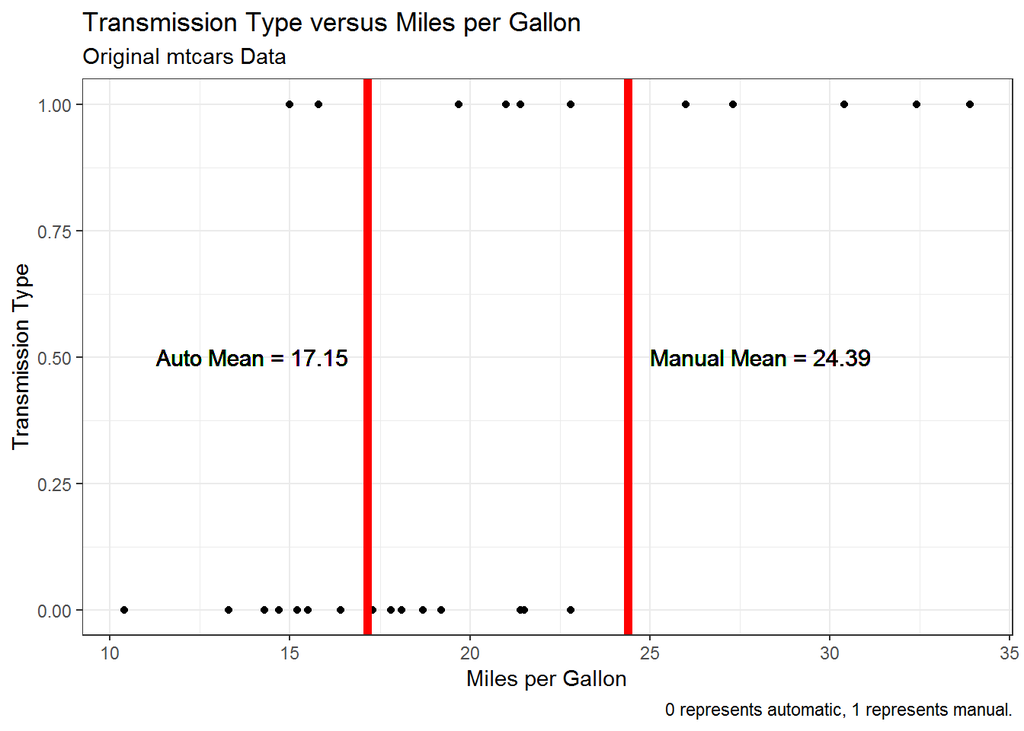

Our plot confirms what the data was telling us, the manual transmissions MPGs have a larger variance than the automatic transmissions. A quick look tells us that while the manual data has a higher variance, none of the data points would constitute an outlier.

## Models

### Linear Regression

To continue our analysis, we now move to applying regression models. First, we will apply a standard linear model.

```
##
## Call:
## lm(formula = mpg ~ ., data = d)
##
## Residuals:
##     Min      1Q  Median      3Q     Max
## -3.5087 -1.3584 -0.0948  0.7745  4.6251
##
## Coefficients:
##             Estimate Std. Error t value Pr(>|t|)
## (Intercept) 23.87913   20.06582   1.190   0.2525
## cyl6        -2.64870    3.04089  -0.871   0.3975
## cyl8        -0.33616    7.15954  -0.047   0.9632
## disp         0.03555    0.03190   1.114   0.2827
## hp          -0.07051    0.03943  -1.788   0.0939 .
## drat         1.18283    2.48348   0.476   0.6407
## wt          -4.52978    2.53875  -1.784   0.0946 .
## qsec         0.36784    0.93540   0.393   0.6997
## vs1          1.93085    2.87126   0.672   0.5115
## amManual     1.21212    3.21355   0.377   0.7113
## gear4        1.11435    3.79952   0.293   0.7733
## gear5        2.52840    3.73636   0.677   0.5089
## carb2       -0.97935    2.31797  -0.423   0.6787
## carb3        2.99964    4.29355   0.699   0.4955
## carb4        1.09142    4.44962   0.245   0.8096
## carb6        4.47757    6.38406   0.701   0.4938
## carb8        7.25041    8.36057   0.867   0.3995
## ---
## Signif. codes:  0 '***' 0.001 '**' 0.01 '*' 0.05 '.' 0.1 ' ' 1
##
## Residual standard error: 2.833 on 15 degrees of freedom
## Multiple R-squared:  0.8931, Adjusted R-squared:  0.779
## F-statistic:  7.83 on 16 and 15 DF,  p-value: 0.000124
```

Table Showing the Original MPG, LM Predicated Coefficients and the LM Residuals.

|  | mpg | predicted | residuals |
| --- | --- | --- | --- |
| Mazda RX4 | 21.0 | 21.37974 | -0.3797416 |
| Mazda RX4 Wag | 21.0 | 20.43064 | 0.5693582 |
| Datsun 710 | 22.8 | 26.30873 | -3.5087294 |
| Hornet 4 Drive | 21.4 | 20.80728 | 0.5927215 |
| Hornet Sportabout | 18.7 | 17.42580 | 1.2741991 |
| Valiant | 18.1 | 18.78540 | -0.6854022 |

From these first two pieces of data, we can see our coefficients, p-values, predicted and residual values from the linear model. While the R^2 is showing a strong fit, our p-values for the coefficient estimates show that we have a lot of regressors that are not statistically signficant to our outcome. Let us remove the least significant regressor, cyl, and see how it affects the rest.

```
##
## Call:
## lm(formula = mpg ~ . - cyl, data = d)
##
## Residuals:
##     Min      1Q  Median      3Q     Max
## -3.1897 -1.3843 -0.3634  0.9201  4.6548
##
## Coefficients:
##             Estimate Std. Error t value Pr(>|t|)
## (Intercept) 12.87276   15.43382   0.834    0.416
## disp         0.03120    0.02420   1.289    0.215
## hp          -0.04916    0.03139  -1.566    0.136
## drat         2.39306    2.19773   1.089    0.291
## wt          -3.89980    2.25665  -1.728    0.102
## qsec         0.52619    0.83550   0.630    0.537
## vs1          1.52262    2.57613   0.591    0.562
## amManual     1.95166    2.80814   0.695    0.496
## gear4        0.88681    3.45338   0.257    0.800
## gear5        1.97540    3.60004   0.549    0.590
## carb2       -0.75477    2.25913  -0.334    0.742
## carb3        2.08122    3.72838   0.558    0.584
## carb4       -1.30096    3.76183  -0.346    0.734
## carb6        0.96288    5.50575   0.175    0.863
## carb8        3.04608    7.39745   0.412    0.686
##
## Residual standard error: 2.779 on 17 degrees of freedom
## Multiple R-squared:  0.8834, Adjusted R-squared:  0.7873
## F-statistic: 9.197 on 14 and 17 DF,  p-value: 2.359e-05
```

We can see that, while our R^2 and residuals remain essentially the same, our p-values have gotten more significant, with “wt” being the most significant at 0.102. I won’t include all the iterations of model here, but the following model is what we found to fit the data the best.

```
##
## Call:
## lm(formula = mpg ~ wt + am + hp + (am * wt), data = mtcars)
##
## Residuals:
##     Min      1Q  Median      3Q     Max
## -3.0639 -1.3315 -0.9347  1.2180  5.0822
##
## Coefficients:
##              Estimate Std. Error t value Pr(>|t|)
## (Intercept) 30.947333   2.723411  11.363 8.55e-12 ***
## wt          -2.515586   0.844497  -2.979  0.00605 **
## am          11.554813   4.023277   2.872  0.00784 **
## hp          -0.026949   0.009796  -2.751  0.01048 *
## wt:am       -3.577910   1.442796  -2.480  0.01968 *
## ---
## Signif. codes:  0 '***' 0.001 '**' 0.01 '*' 0.05 '.' 0.1 ' ' 1
##
## Residual standard error: 2.332 on 27 degrees of freedom
## Multiple R-squared:  0.8696, Adjusted R-squared:  0.8503
## F-statistic: 45.01 on 4 and 27 DF,  p-value: 1.451e-11
```

Table Showing the Original MPG, LM Predicated Coefficients and the LM Residuals.

|  | mpg | predicted | residuals |
| --- | --- | --- | --- |
| Mazda RX4 | 21.0 | 23.57276 | -2.572760 |
| Mazda RX4 Wag | 21.0 | 22.01892 | -1.018919 |
| Datsun 710 | 22.8 | 25.85895 | -3.058948 |
| Hornet 4 Drive | 21.4 | 19.89530 | 1.504703 |
| Hornet Sportabout | 18.7 | 17.57758 | 1.122417 |
| Valiant | 18.1 | 19.41373 | -1.313726 |

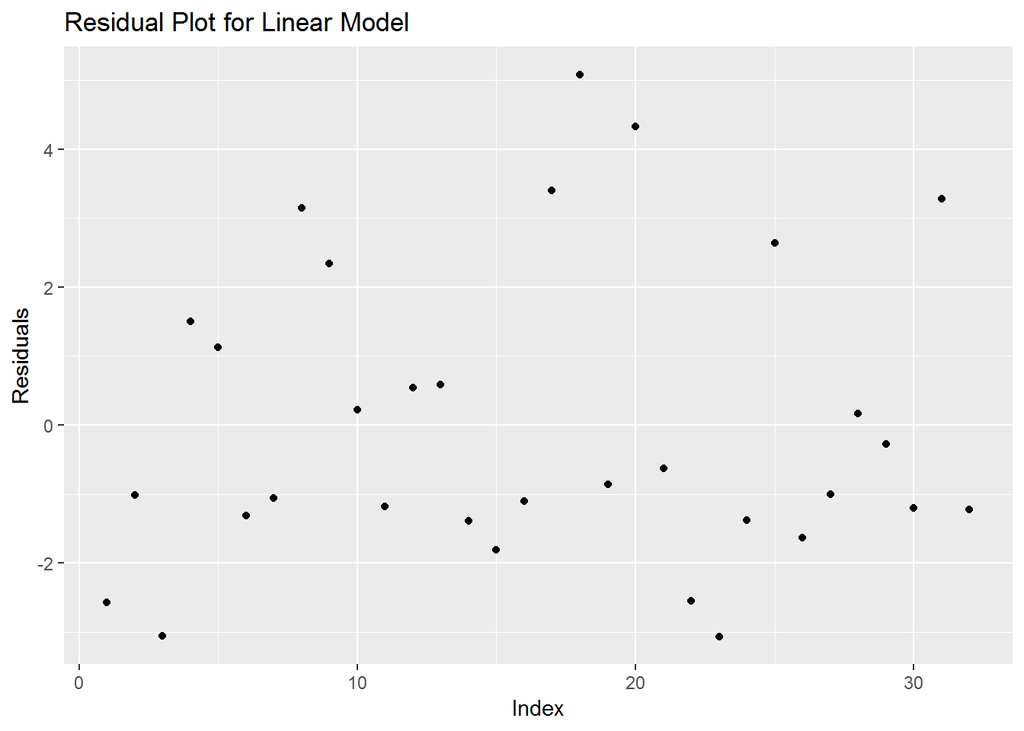

The residual plot shows no apparant pattern, which lends credence to the use of our model.

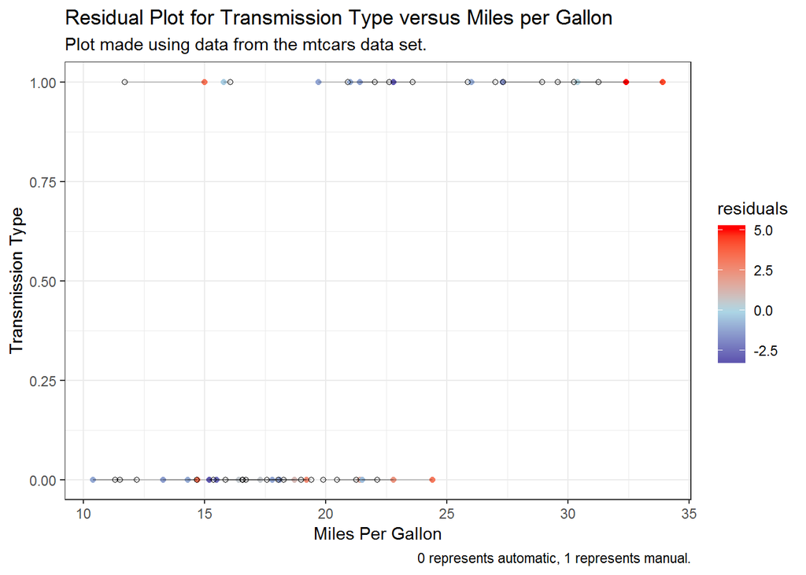

To keep the focus of this paper on the orignal question, the plots for the remaining regressors will be available in the appendix. Above, we have a nicer plot of the actual values connected to the predicted values with the residual values included as a color gradient. This is simply a more appealing way to show the relationship of the residuals to the actual values.

## Inference

Our final analysis will be performing a two sample t-test with the two transmission types.

```
##
##  Welch Two Sample t-test
##
## data:  mpg by am
## t = -3.7671, df = 18.332, p-value = 0.001374
## alternative hypothesis: true difference in means is not equal to 0
## 95 percent confidence interval:
##  -11.280194  -3.209684
## sample estimates:
## mean in group 0 mean in group 1
##        17.14737        24.39231
```

What we see here is that with a p-value of 0.001, We can reject the null hypothesis and conclude that the mean mpg of manual transmission is significantly different from the mean mpg of automatic transmissions.

## Summary

Through the use of central tendency evaluation, and then the application of multiple linear regression, we can conclude that, in 1974, manual tranmissions were more fuel efficient, on average, than automatic transmissions. However, we discovered that the weight of the vehicle was the most signficant factor to determine a cars mileage, and that horsepower and the interaction between weight and transmission type were all significant factors.

## Appendix

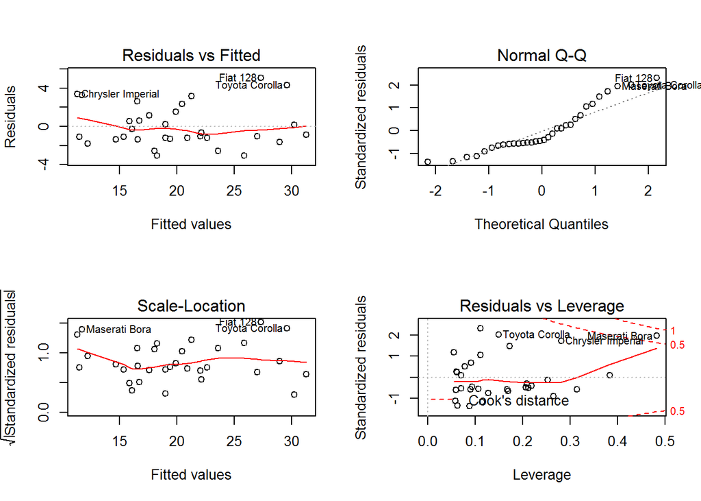

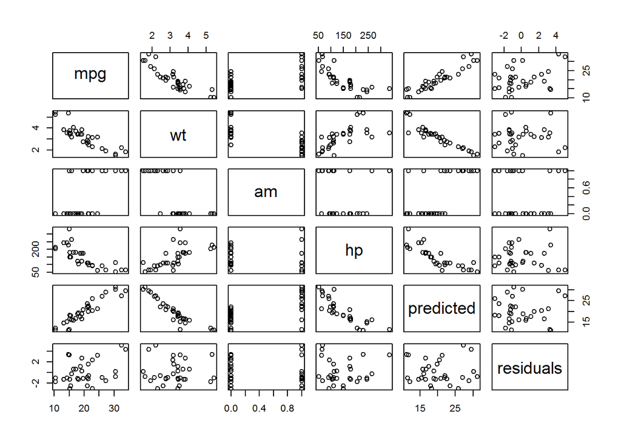

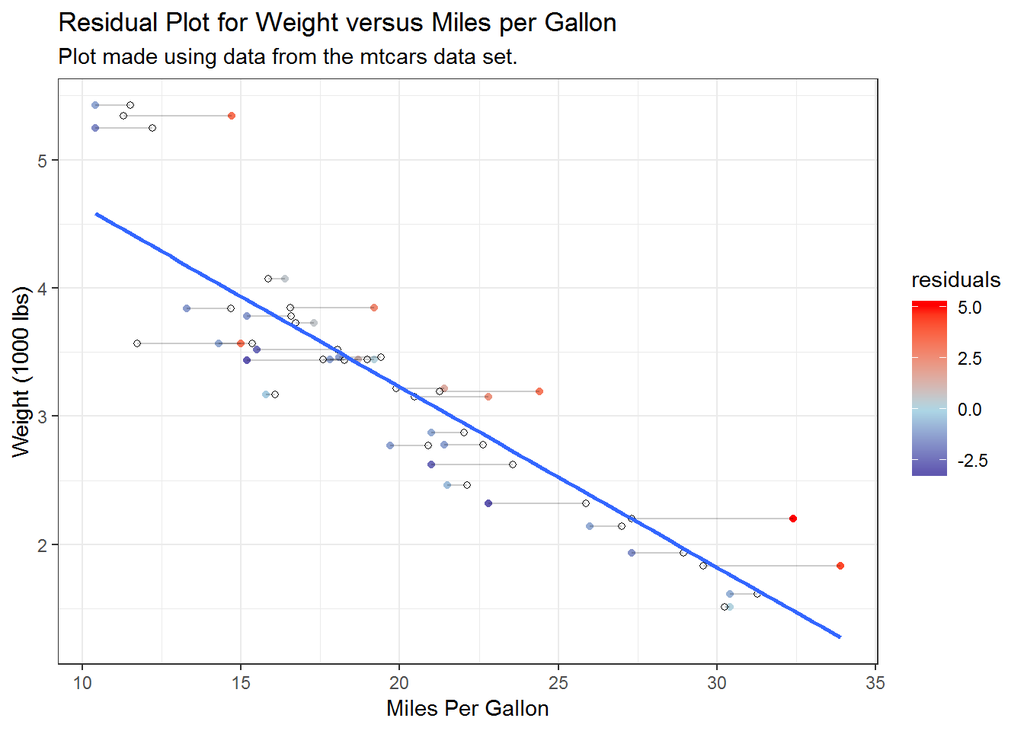

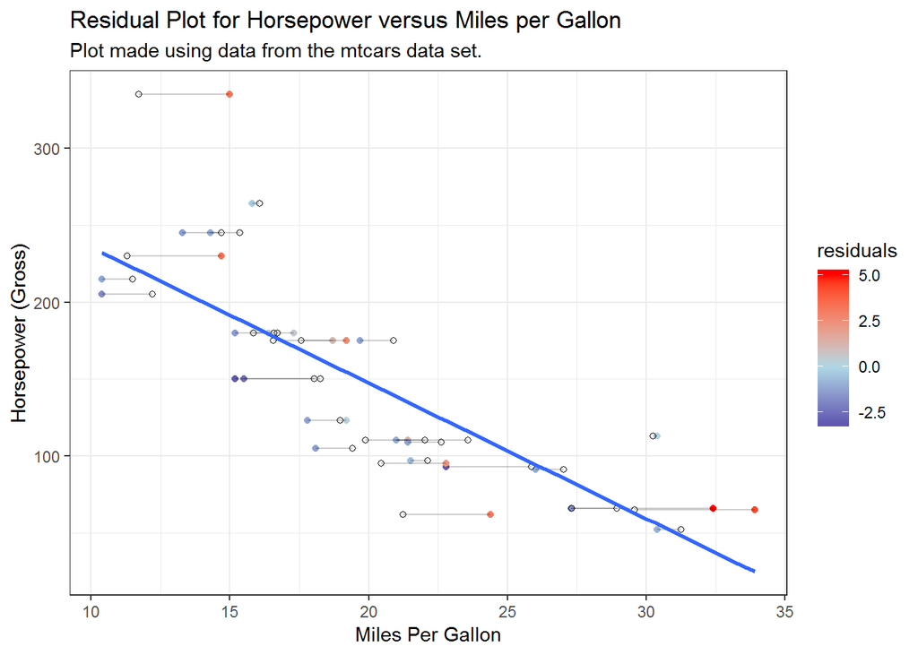